# Question

A bowl is designed as the revolution of the region between 3 curves:
$$z=5x-43$$

$$z=\frac{7}{100}x^2$$

$$z=0$$

The revolution occurs around the $z$ axis. The bowl will be made of wood.

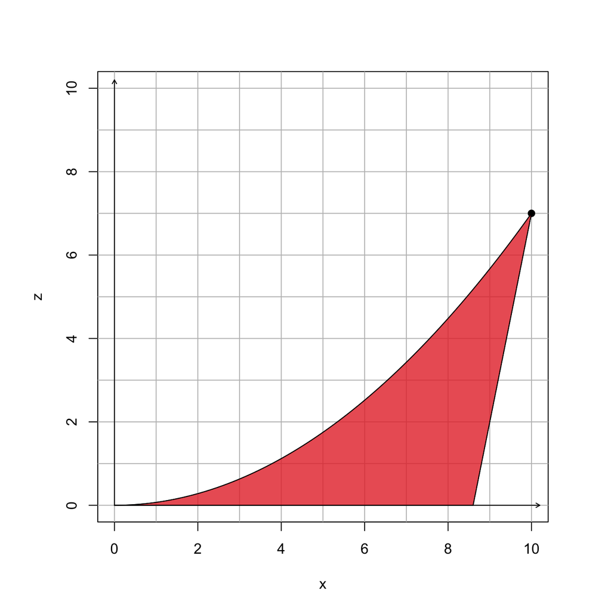

Notice the point of intersection is $(10, 7)$. Below is a wireframe animation of the bowl.

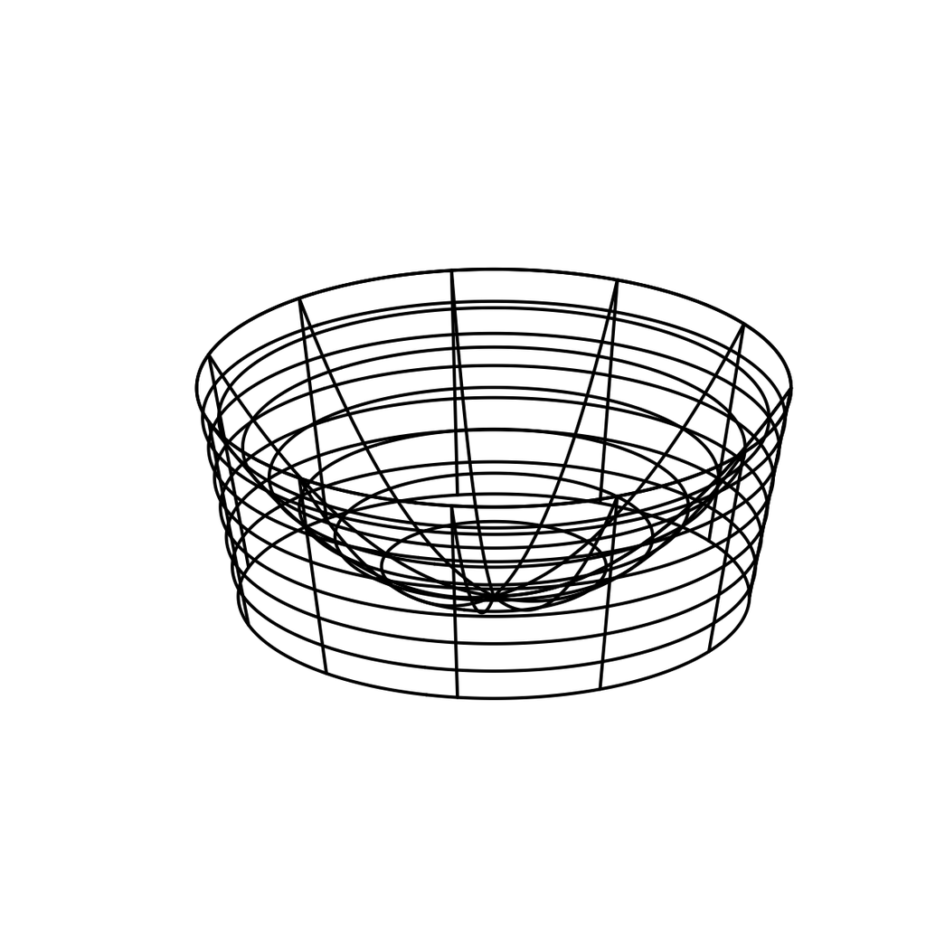

Find the volume of the wood composing the bowl. I’d recommend using the [washer method](https://en.wikipedia.org/wiki/Disc_integration#Washer_method). The tolerance is $\pm 1$ cubic units.

# Solution

We will use the [washer method](https://en.wikipedia.org/wiki/Disc_integration#Washer_method). Notice we can approximate the shape with a bunch of thin washers.

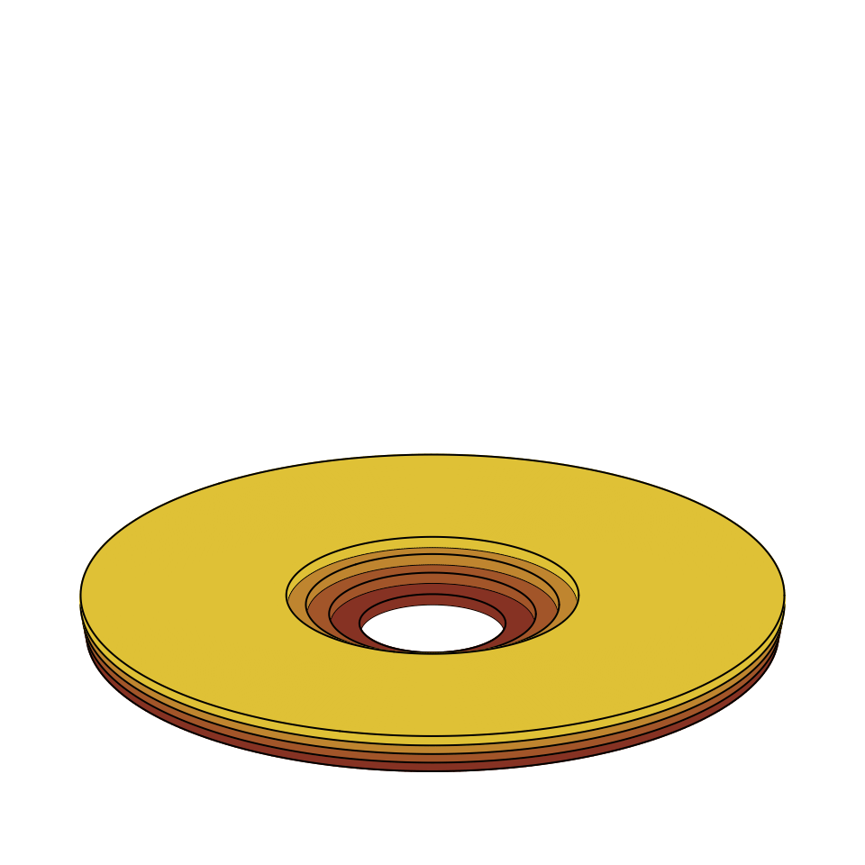

Each washer has two radii (inner and outer) and an infinitesimal thickness.

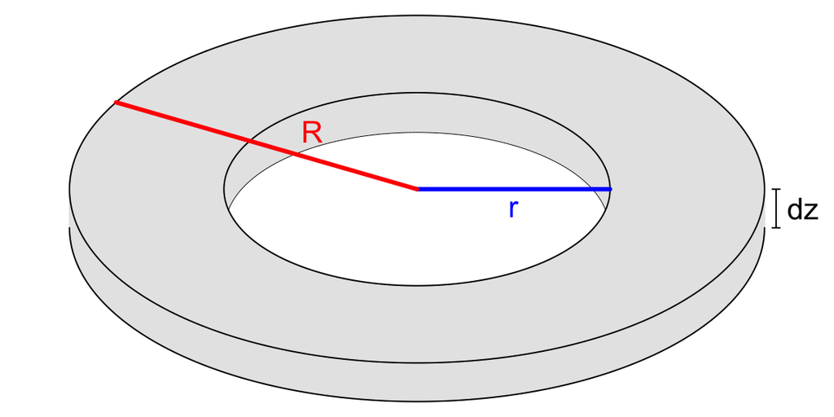

The infinitesimal volume for each washer can be expressed in terms of $r$, $R$, and $dz$.

$$dV ~=~ \pi \left(R^2 - r^2\right) \,
dz$$

We need to express $R$ and $r$ as functions of $z$. Notice that $R$ is equivalent to $x$ in the linear equation and $r$ is equivalent to $x$ in the quadratic equation. Let’s start by finding $R$ in terms of $z$.

$$z = 5R-43$$

Solve for $R$.

$$R = \frac{z+43}{5}$$

Now, let’s get $r$ in terms of $z$.

$$z = \frac{7}{100}r^2$$

Solve for $r$.

$$r = \sqrt{\frac{100z}{7}}$$

To get the volume, we need to sum up a bunch of washer volumes as $z$ progresses from 0 to 7.

$$V = \int_{z=0}^{z=7} dV$$

$$V = \int_{0}^{7}
\pi\left(R^2-r^2\right)\,dz$$

$$V = \int_{0}^{7}
\pi\left(\left(\frac{z+43}{5}\right)^2-\left(\sqrt{\frac{100z}{7}}\right)^2\right)\,dz$$

A constant multiplier can be pulled out of an integral.

$$V = \pi \int_{0}^{7}
\left(\left(\frac{z+43}{5}\right)^2-\left(\sqrt{\frac{100z}{7}}\right)^2\right)\,dz$$

Honestly, at this point, you probably want to use Desmos. It understands definite integrals. You can get the integration symbol by typing `int`.

If you want to work it out algebraically, remember [binomial expansion](https://en.wikipedia.org/wiki/Binomial_theorem).

$$V = \pi \int_{0}^{7}
\left(\frac{1}{25}z^2+\frac{86}{25}z+\frac{1849}{25}-\frac{100}{7}z\right)\,dz$$

Combine like terms.

$$V = \pi \int_{0}^{7}
\left(\frac{1}{25}z^2+\left(\frac{86}{25}-\frac{100}{7}\right)z+\frac{1849}{25}\right)\,dz$$

Use the antiderivative. We use the square brackets and rewriting the limits to remember to put them into the antiderivative (and take a difference).

$$V =
\pi \left[\frac{1}{75}z^3+\left(\frac{86}{50}-\frac{100}{14}\right)z^2+\frac{1849}{25}z\right]_{0}^{7}$$

Plug in the limits and take a difference.

$$V = \pi \left[
\left(\frac{1}{75}(7)^3+\left(\frac{86}{50}-\frac{100}{14}\right)(7)^2+\frac{1849}{25}(7)\right)-\left(\frac{1}{75}(0)^3+\left(\frac{86}{50}-\frac{100}{14}\right)(0)^2+\frac{1849}{25}(0)\right)
\right]$$

Anything times 0 is 0.

$$V = \pi
\left(\frac{1}{75}(7)^3+\left(\frac{86}{50}-\frac{100}{14}\right)(7)^2+\frac{1849}{25}(7)\right)$$

$$V=806.0488991$$

# Meta-information

extype: num exsolution: 806.0488991 exname: vol_by_washers extol: 1